# Lab1 - Gapminder Plots and computations

Author

Lucas Calaff

```python
import pandas as pd
import numpy as np
import plotnine as p9
```

https://github.com/lcalaff/Pyython_Work/tree/main/LAB1

### Task 1: Using the Q1 Dataset to recreate the visualization shown in Gapminder

#### 1. The Variables that we can take note of in this visualization is y values of life expectancy, x value of income, colors of the four regions, and increased size of each circle depending on size of the data point

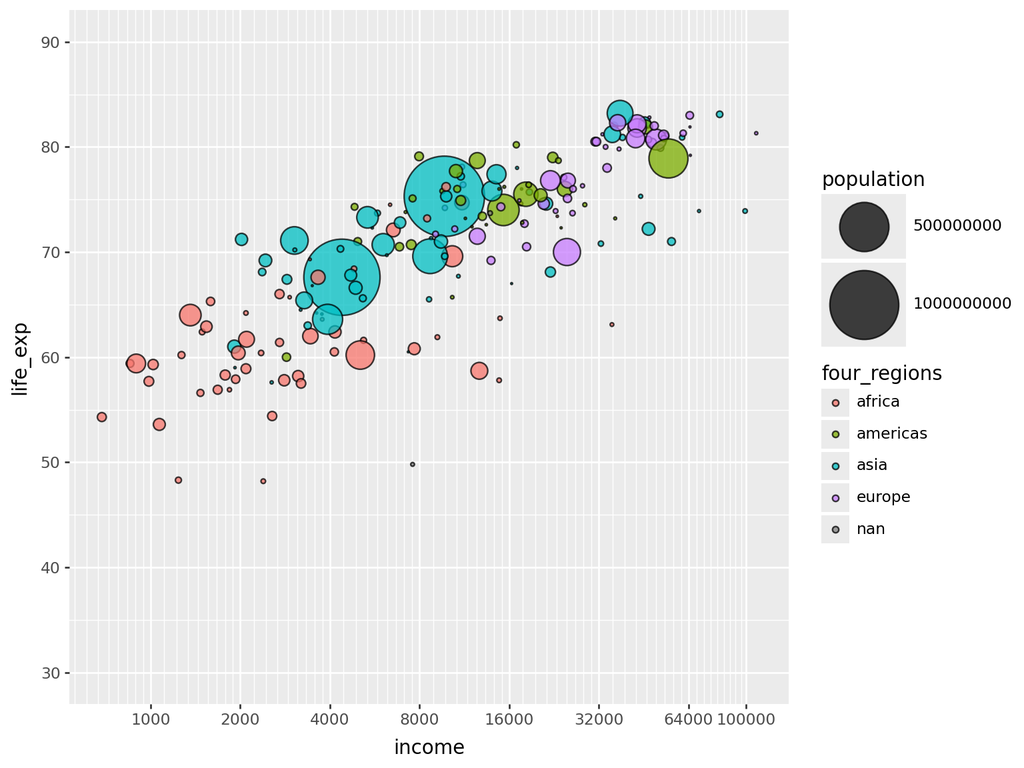

```python
q1 = pd.read_csv(r"C:\Users\ldcal\OneDrive\Desktop\Cal Poly Courses\Fall\GSB-S544\Coding Work\Pyython_Work\LAB1\Data\q1data.csv")


(p9.ggplot(q1,p9.aes(
    x="income",
    y="life_exp",
    fill = "four_regions",
    size = "population",

))
+p9.theme(figure_size=(8,6))
+ p9.scale_size_area(max_size=25)

+p9.scale_x_log10(breaks=[500,1000,2000,4000,8000,16000,32000,64000,100000])
+p9.scale_y_continuous(limits = (30,90),
 breaks=np.arange(30, 90.1, 10))
+ p9.geom_point(alpha = 0.75)
)
```

#### Using a different style of plot to model the q1 data

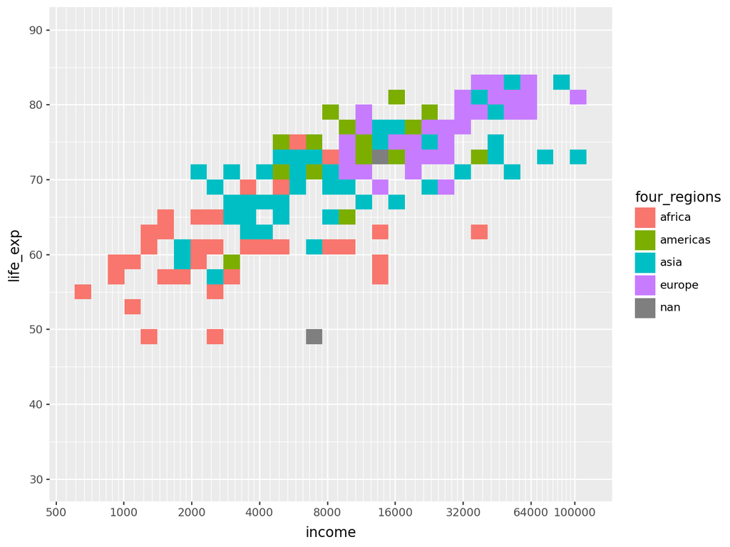

```python
(p9.ggplot(q1,p9.aes(
    x="income",
    y="life_exp",
    fill = "four_regions",
    size = "population",

))
+p9.theme(figure_size=(8,6))
+ p9.scale_size_area(max_size=25)

+p9.scale_x_log10(breaks=[500,1000,2000,4000,8000,16000,32000,64000,100000])
+p9.scale_y_continuous(limits = (30,90),
 breaks=np.arange(30, 90.1, 10))
 +p9.geom_bin2d()
 )
```

This plot that was used has a lot of simmilar attirbutes and in my opnion does a better job to show the colors and more spesifically the keys of which region is represented. It however doesnt do a greate job to show the population densisties as every rectangle is the same size. It also doesnt do a great job at repsenting the overlapping regions with eachother.

### Task 2: Using the q2 dataset in order to visualize and recreate the gapminder figure

```python
#used chatGPT to create this function once i noticed that there were values
#in the energy column that were instances like 12.2k and made the entire column
#a string instead of a float

def convert_k_to_float(value):
    if isinstance(value, str):
        if 'k' in value.lower():
            # Remove 'k' and convert to float, then multiply by 1000
            return float(value.lower().replace('k', '')) * 1000
        elif 'm' in value.lower():
            # Handle 'm' for millions, if needed
            return float(value.lower().replace('m', '')) * 1000000
        else:
            # Handle standard numeric strings
            return float(value)
    # Return the value unchanged if it's already a number or NaN
    return value
```

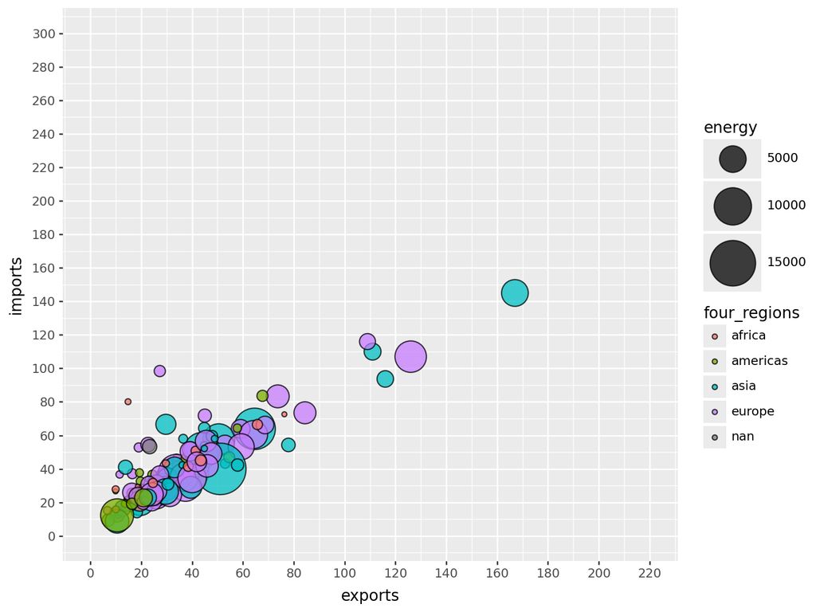

```python
q2 = pd.read_csv(r"C:\Users\ldcal\OneDrive\Desktop\Cal Poly Courses\Fall\GSB-S544\Coding Work\Pyython_Work\LAB1\Data\q2data.csv")

q2["energy"] = q2["energy"].apply(convert_k_to_float)



(p9.ggplot(q2, p9.aes(
    x= "exports",
    y= "imports",
    fill = "four_regions",
    size = "energy"

)) +p9.theme(figure_size=(8,6))

+ p9.scale_size_area(max_size=20)

+p9.scale_x_continuous(limits = (0,220),
 breaks=np.arange(0, 220.1, 20))

+p9.scale_y_continuous(limits = (0,300),
 breaks=np.arange(0, 300.1, 20))
+ p9.geom_point(alpha = .75))
```

#### Using another syle of plot to graph q2 data

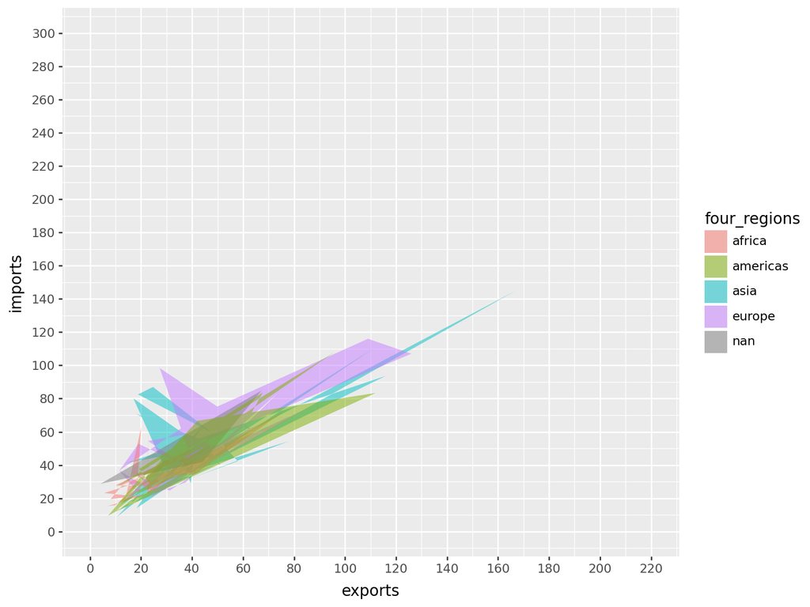

```python
(p9.ggplot(q2, p9.aes(
    x= "exports",
    y= "imports",
    fill = "four_regions",

)) +p9.theme(figure_size=(8,6))

+ p9.scale_size_area(max_size=20)

+p9.scale_x_continuous(limits = (0,220),
 breaks=np.arange(0, 220.1, 20))

+p9.scale_y_continuous(limits = (0,300),
 breaks=np.arange(0, 300.1, 20))
+ p9.geom_polygon(alpha = 0.50))
```

as we can observe in this data we can tell pretty easily that asia has an outlier for the exports and imports, however africa appears to be a little more covered up and not easily identifiable.

### Task 3: Using the q3 dataset to recreate the visualization that gapminder made

#### This figure uses data from 2001 with the x variable being individuals who use the internet, and the Y variables being GDP/ capita, the colors a represented by world regions again and the size of each individual dot corresponds to the income of that given region.

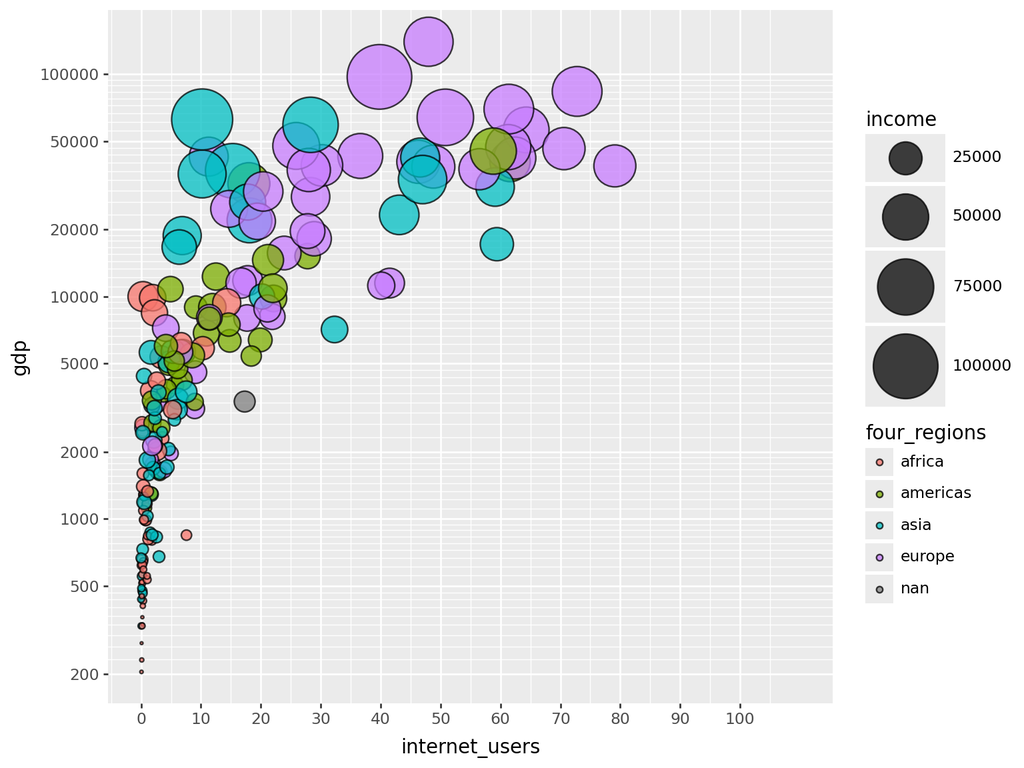

```python
q3 = pd.read_csv(r"C:\Users\ldcal\OneDrive\Desktop\Cal Poly Courses\Fall\GSB-S544\Coding Work\Pyython_Work\LAB1\Data\q3data.csv")

(p9.ggplot(q3, p9.aes(
    x= "internet_users",
    y= "gdp",
    fill = "four_regions",
    size = "income"

)) +p9.theme(figure_size=(8,6))

+ p9.scale_size_area(max_size=20)

+p9.scale_x_continuous(limits = (0,110),
 breaks=np.arange(0, 110, 10))

+p9.scale_y_log10(breaks = [200,500,1000,2000,5000,10000,20000,50000,100000])
+ p9.geom_point(alpha = .75))
```

#### Using a different style of plot for the q3 data

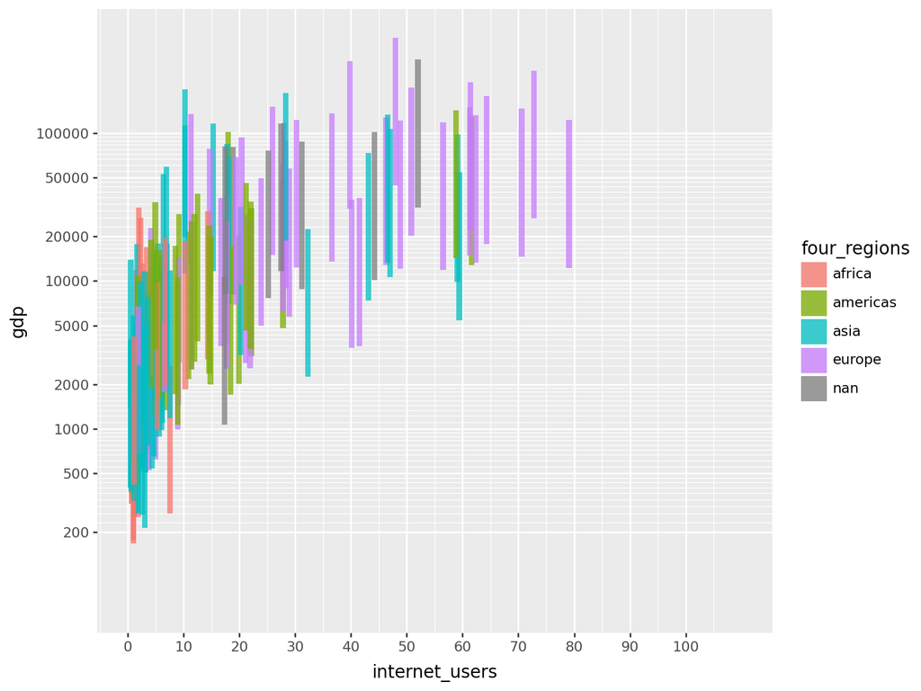

```python
(p9.ggplot(q3, p9.aes(
    x= "internet_users",
    y= "gdp",
    fill = "four_regions",

)) +p9.theme(figure_size=(8,6))

+ p9.scale_size_area(max_size=20)

+p9.scale_x_continuous(limits = (0,110),
 breaks=np.arange(0, 110, 10))

+p9.scale_y_log10(breaks = [200,500,1000,2000,5000,10000,20000,50000,100000])
+ p9.geom_tile(alpha = .75))
```

An advantage for this graph is that its x values are very precise in terms of who close they are to the actual values in the data. however the gdp shows more of an estimate which can be both a disadvantage and advantage as we could use this to find simmilar regions of data but would be unsure how skewed the results were.